# 002_ПродолжениеС++_v2

### Пример второй

[figure not shown]

```julia
c = x;
01522966  mov         eax,dword ptr [ebp-8]
01522969  mov         dword ptr [ebp-0Ch],eax
    x = y;
0152296C  mov         eax,dword ptr [ebp-4]
0152296F  mov         dword ptr [ebp-8],eax
    y = c;
01522972  mov         eax,dword ptr [ebp-0Ch]
01522975  mov         dword ptr [ebp-4],eax
```

[figure not shown]

Можно и короче

[figure not shown]

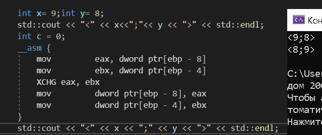

[figure not shown]

Совет. Если пишите программный код, по-началу очищайте используемые регистры. **XOR EAX,EAX**. Это избавит от мусора в регистрах...

### Пример третий

```julia
#include "pch.h"
#include <iostream>
int main()
{
    //переременная x
    int x = 9;
    //переременная y
    int y = 8;
    //Указатель на пернеменную yy
    int* yy = &y;
    std::cout << "x=" << x << std::endl;
    std::cout << "y=" << y << std::endl;
    //Обращение к адресу оперативной памяти переменной
    std::cout << "&y=" << &y << std::endl;
    //Просто посмотреть - что внутри указателя
    std::cout << "yy=" << yy << std::endl;
    //Обращение к значению по удресу из указателя
    std::cout << "*yy=" << *yy << std::endl;
    _asm
    {
        xor eax, eax
        xor ebx, ebx
        mov         eax, dword ptr[x]
        mov         ecx, dword ptr[yy]
        // Обращаемся к переменной указателя
        // Получаем содержимое переменной указателя в регистр ecx
        mov         ebx, dword ptr[ecx]
        //Теперь ecx содержит указатель на переменную y
        //Получаем значение переменной y в ebx
        XCHG eax, ebx
        mov          dword ptr[x], eax
        mov          dword ptr[ecx], ebx
        //Кладем значение в переменную y
        //ecx содержит указатель на переменную y
    }
    std::cout << "x=" << x << std::endl;
    std::cout << "y=" << y << std::endl;
}
```

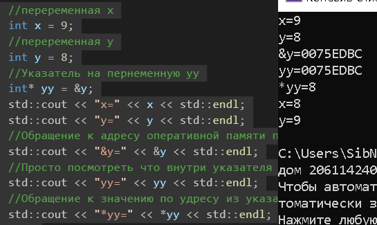

Внимание, при копировании текста в Visual Studio 2019 некоторые символы вставляются как символы других кодов, но с тем же внешним видом. В таких случаях рекомендуется либо создать новый проект, либо в Visual Studio набрать код с клавиатуры.

### Пример четвертый

Работа с массивами на Ассемблере ведется по тем же принципам, что и работа с массивами в с++ через арифметику указателей. Вот пример.

```julia
#include "pch.h"
#include <iostream>
int main()
{
    //переременная x
    int x = 0;
    //Создали одномерный массив из 3 элементов
    int a[3] = { 1, 2, 3 };
    //Создали символ
    char MyChar = '*';
    //Вывели наш массив на экран в стиле аля питон
    std::cout << "a={" << a[0] << "," << a[1] << "," << a[2] << "," << "}" << std::endl;
    //Вывели на экран весь массив, и вдруг выяснилось, что это указатель
    std::cout << "a=" << a << std::endl;
    std::cout << "x=" << x << std::endl;
    //Получили размер переменной x, которая int
    std::cout << "sizeof(x)=" << sizeof(x) << std::endl;//=4
    //Получили размер всего нашего массива (он 12) из 3 элементов размером по 4
    std::cout << "sizeof(a)=" << sizeof(a) << std::endl;
    std::cout << "MyChar=" << MyChar << std::endl;
    //Вывели размер символа
    std::cout << "sizeof(MyChar)=" << sizeof(MyChar) << std::endl;
    //Вывели на экран первый элемент массива, обратившись к нему через Ассемблер
    std::cout << "a[0]=";
    _asm
    {
        xor eax, eax
        mov eax, dword ptr[a]
        mov dword ptr[x], eax
    }
    std::cout << x << std::endl;
    //Вывели на экран первый элемент массива, обратившись к нему через Ассемблер
    //НЕ ЗАБЫЛИ У INT ПРО РАЗМЕР И ДОПИСАЛИ СМЕЩЕНИЕ В ОПЕРАТИВНОЙ ПАМЯТИ +4
    std::cout << "a[1]=";
    _asm
    {
        xor eax, eax
        mov eax, dword ptr[a + 4 * 1]
        mov dword ptr[x], eax
    }
    std::cout << x << std::endl;
    //+4 2 раза
    std::cout << "a[2]=";
    _asm
    {
        xor eax, eax
        mov eax, dword ptr[a + 4 * 2]
        mov dword ptr[x], eax
    }
    std::cout << x << std::endl;
    //Обратились к 4, несуществующему элементу массива
    //Получили мусор
    std::cout << "a[3]=";
    _asm
    {
        xor eax, eax
        mov eax, dword ptr[a + 4 * 3]
        mov dword ptr[x], eax
    }
    std::cout << x << std::endl;
}
```

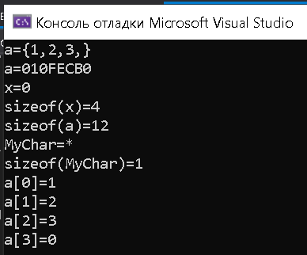

# Лабораторная работа

Задание взято из "Архитектура ЭВМ. Задания и примеры выполнения лабораторных работ. Медодические указания/ сост. : А.Е. Докторов, Е. А. Докторова. - Ульяновск : УлГТУ, 2008. - 32 с".  
**Тема лабораторной работы. 64 битные операции на 32 битной машине** Выставляем в Visual Studio "Debug x86". После этого программный код будет генерироваться 32 битным даже на 64 битной машине.

[figure not shown]

Далее рекомендуется дать на самостоятельный поиск по источникам из Интернета следующие команды. Также их краткие описания можно посмотреть в $[А.Е. Докторов.2008]$

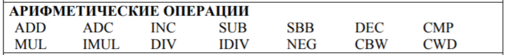

Требуется написать ассемблерную вставку сложения (вычитания) двух 64 битных чисел.

```julia
#include "pch.h"
#include <iostream>
int main()
{
    __int64  c=0;
    __int64  x;
    x = 4;
    __int64  y;
    y = 6;
    c = x + y;
    std::cout <<"x=" << x << std::endl;
    std::cout << "y=" << y << std::endl;
    std::cout << "c=" << c << std::endl;
}
```

```julia
__int64  x;
    x = 4;
0068290F  mov         eax,4
00682914  cdq
00682915  mov         dword ptr [ebp-10h],eax
00682918  mov         dword ptr [ebp-0Ch],edx
    __int64  y;
    y = 6;
0068291B  mov         eax,6
00682920  cdq
00682921  mov         dword ptr [ebp-8],eax
00682924  mov         dword ptr [ebp-4],edx
    __int64  c=0;
    c = x + y;
00682927  mov         eax,dword ptr [ebp-10h]
0068292A  mov         edx,dword ptr [ebp-0Ch]
0068292D  add         eax,dword ptr [ebp-8]
00682930  adc         edx,dword ptr [ebp-4]
00682933  mov         dword ptr [ebp-18h],eax
00682936  mov         dword ptr [ebp-14h],edx
    c = x - y;
00EE2927  mov         eax,dword ptr [ebp-10h]
00EE292A  mov         edx,dword ptr [ebp-0Ch]
00EE292D  sub         eax,dword ptr [ebp-8]
00EE2930  sbb         edx,dword ptr [ebp-4]
00EE2933  mov         dword ptr [ebp-18h],eax
00EE2936  mov         dword ptr [ebp-14h],edx
```

Последующие темы по методическим указаниям [Докторов 2008]:

- Изучение логических команд и команд сдвигов.
- Изучение команд обработки блоков данных. Цикл LOOP. Обработка текстов.
- Изучение команд условного перехода.
- Изучение команд передачи управления.  
  Но не так все просто.  
  Команда LOOP работает только в Pascal ранних версий и DosBox.  
  Некоторых команд обработки данных нет в современном ассемблере. Их заменяют своими процедурами и работой через указатели.  
  Потому, с этого момента [Докторов 2008] будет использован нами как дополнительный материал.  
  Мы плавно переключаемся на программирование под DosBox на FlatAssembler1.71.  
  Сайт [FasmWorld.](https://fasmworld.ru/uchebnik/)  
  Продолжение следует...